# Problem Set#2

Author

Jialiang Wu

For source files and data, see my GitHub repo: [STATS-506-Problem-Sets-02](https://github.com/CrispyShyYi/STATS-506-Problem-Sets/tree/main/set-2)

# set-up

```r
library(microbenchmark)
library(dplyr)
```

# Problem Ser 1 - Modified Random walk

## question a

```r
#' Random Walk using Loop
#'
#' Implements a 1D random walk with given rules using a for loop.
#'
#' @param n Integer. Number of steps in the random walk.
#' @return Final position after n steps.
#' @examples
#' random_walk1(10)
random_walk1 <- function(n) {
  pos <- 0
  for (i in 1:n) {
    step <- sample(c(-1, 1), 1)
    if (step == 1) {
      # 5% chance to take +10 instead
      if (runif(1) < 0.05) {
        step <- 10
      }
    } else {
      # 20% chance to take -3 instead
      if (runif(1) < 0.20) {
        step <- -3
      }
    }
    pos <- pos + step
  }
  return(pos)
}

#' Random Walk using Vectorization
#'
#' Implements a 1D random walk using R's vectorized functions (no loops).
#'
#' @param n Integer. Number of steps in the random walk.
#' @return Final position after n steps.
#' @examples
#' random_walk2(10)
random_walk2 <- function(n) {
  steps <- sample(c(-1, 1), n, replace = TRUE)  # base steps

  # replace +1 with +10 in 5% of cases
  plus_idx <- which(steps == 1 & runif(n) < 0.05)
  steps[plus_idx] <- 10

  # replace -1 with -3 in 20% of cases
  minus_idx <- which(steps == -1 & runif(n) < 0.20)
  steps[minus_idx] <- -3

  return(sum(steps))
}

#' Random Walk using Apply
#'
#' Implements a 1D random walk using one of the apply family functions.
#'
#' @param n Integer. Number of steps in the random walk.
#' @return Final position after n steps.
#' @examples
#' random_walk3(10)
random_walk3 <- function(n) {
  steps <- sapply(1:n, function(i) {
    step <- sample(c(-1, 1), 1)
    if (step == 1) {
      if (runif(1) < 0.05) return(10) else return(1)
    } else {
      if (runif(1) < 0.20) return(-3) else return(-1)
    }
  })
  return(sum(steps))
}
```

demonstrate three functions use following cases

```r
random_walk1(10)
```

```
[1] 1
```

```r
random_walk2(10)
```

```
[1] 2
```

```r
random_walk3(10)
```

```
[1] 11
```

```r
random_walk1(1000)
```

```
[1] 104
```

```r
random_walk2(1000)
```

```
[1] 15
```

```r
random_walk3(1000)
```

```
[1] 37
```

## question b

update functions to receive extra parameters for set random steps

```r
#' Make RNG streams for the random walk
#'
#' @param n Integer. Number of steps.
#' @param seed Integer or NULL. If provided, sets the RNG seed.
#' @return A list with three numeric vectors in [0,1): dir_u, plus_u, minus_u
#' @examples
#' streams <- make_streams(10, seed = 123)
make_streams <- function(n, seed = NULL) {
  if (!is.null(seed)) set.seed(seed)
  list(
    dir_u   = runif(n),  # for base +/-1 choice
    plus_u  = runif(n),  # for the "+10 with prob 0.05" test (only used when base is +1)
    minus_u = runif(n)   # for the "-3 with prob 0.20" test (only used when base is -1)
  )
}

#' Random Walk (loop)
#'
#' @param n Integer. Number of steps.
#' @param dir_u,plus_u,minus_u Optional numeric vectors in [0,1) of length n.
#'   If NULL, fresh random numbers are generated internally.
#' @return Final position after n steps.
#' @examples
#' s <- make_streams(10, seed = 123)
#' random_walk1(10, s$dir_u, s$plus_u, s$minus_u)  # controlled
random_walk1 <- function(n, dir_u = NULL, plus_u = NULL, minus_u = NULL) {
  if (is.null(dir_u) || is.null(plus_u) || is.null(minus_u)) {
    tmp <- make_streams(n)
    dir_u   <- tmp$dir_u
    plus_u  <- tmp$plus_u
    minus_u <- tmp$minus_u
  }
  pos <- 0
  for (i in seq_len(n)) {
    base <- if (dir_u[i] < 0.5) -1 else 1
    if (base == 1) {
      step <- if (plus_u[i] < 0.05) 10 else 1
    } else {
      step <- if (minus_u[i] < 0.20) -3 else -1
    }
    pos <- pos + step
  }
  pos
}

#' Random Walk (vectorized)
#'
#' @param n Integer. Number of steps.
#' @param dir_u,plus_u,minus_u Optional numeric vectors in [0,1) of length n.
#'   If NULL, fresh random numbers are generated internally.
#' @return Final position after n steps.
#' @examples
#' s <- make_streams(10, seed = 123)
#' random_walk2(10, s$dir_u, s$plus_u, s$minus_u)
random_walk2 <- function(n, dir_u = NULL, plus_u = NULL, minus_u = NULL) {
  if (is.null(dir_u) || is.null(plus_u) || is.null(minus_u)) {
    tmp <- make_streams(n)
    dir_u   <- tmp$dir_u
    plus_u  <- tmp$plus_u
    minus_u <- tmp$minus_u
  }
  base <- ifelse(dir_u < 0.5, -1, 1)
  steps <- ifelse(
    base == 1,
    ifelse(plus_u < 0.05, 10, 1),
    ifelse(minus_u < 0.20, -3, -1)
  )
  sum(steps)
}

#' Random Walk (apply)
#'
#' @param n Integer. Number of steps.
#' @param dir_u,plus_u,minus_u Optional numeric vectors in [0,1) of length n.
#'   If NULL, fresh random numbers are generated internally.
#' @return Final position after n steps.
#' @examples
#' s <- make_streams(10, seed = 123)
#' random_walk3(10, s$dir_u, s$plus_u, s$minus_u)
random_walk3 <- function(n, dir_u = NULL, plus_u = NULL, minus_u = NULL) {
  if (is.null(dir_u) || is.null(plus_u) || is.null(minus_u)) {
    tmp <- make_streams(n)
    dir_u   <- tmp$dir_u
    plus_u  <- tmp$plus_u
    minus_u <- tmp$minus_u
  }
  steps <- sapply(seq_len(n), function(i) {
    base <- if (dir_u[i] < 0.5) -1 else 1
    if (base == 1) {
      if (plus_u[i] < 0.05) 10 else 1
    } else {
      if (minus_u[i] < 0.20) -3 else -1
    }
  })
  sum(steps)
}
```

demonstrate these three functions have the same results

```r
## n = 10
s10 <- make_streams(10, seed = 42)
v1_10 <- random_walk1(10,   s10$dir_u, s10$plus_u, s10$minus_u)
v2_10 <- random_walk2(10, s10$dir_u, s10$plus_u, s10$minus_u)
v3_10 <- random_walk3(10,  s10$dir_u, s10$plus_u, s10$minus_u)

cat("n=10 -> loop:", v1_10, " vectorized:", v2_10, " apply:", v3_10, "\n")
```

```
n=10 -> loop: 6  vectorized: 6  apply: 6
```

```r
## n = 1000
s1k <- make_streams(1000, seed = 42)
v1_1k <- random_walk1(1000,   s1k$dir_u, s1k$plus_u, s1k$minus_u)
v2_1k <- random_walk2(1000, s1k$dir_u, s1k$plus_u, s1k$minus_u)
v3_1k <- random_walk3(1000,  s1k$dir_u, s1k$plus_u, s1k$minus_u)

cat("n=1000 -> loop:", v1_1k, " vectorized:", v2_1k, " apply:", v3_1k, "\n")
```

```
n=1000 -> loop: 14  vectorized: 14  apply: 14
```

## question c

```r
run_bench <- function(n, seed = 42) {
  s <- make_streams(n, seed = seed)  # same streams for all runs
  microbenchmark(
    loop = random_walk1(n, s$dir_u, s$plus_u, s$minus_u),
    vectorized = random_walk2(n, s$dir_u, s$plus_u, s$minus_u),
    apply = random_walk3(n, s$dir_u, s$plus_u, s$minus_u)
  )
}

# case n = 10,000
bench_1k <- run_bench(10000)
print(bench_1k)
```

```
Unit: microseconds
       expr      min        lq      mean    median        uq      max neval
       loop  492.246  505.1200  520.8140  514.0785  537.1205  566.661   100
 vectorized  447.679  499.8105  523.0513  518.4860  546.3250  647.103   100
      apply 3527.640 3614.5395 3912.9441 3677.4130 3780.6305 7467.822   100
```

## question d

Use Monte Carlo simulation

```r
prob_sum_zero <- function(n, trials = 1e6, seed = 123) {
  set.seed(seed)
  # Draw base directions: +1 or -1 (0.5 each)
  base <- sample(c(1L, -1L), size = n * trials, replace = TRUE)
  u <- runif(n * trials)
  # Apply replacements in-place
  # with prob 0.05, +1 becomes +10
  base[base == 1L & u < 0.05]  <- 10L
  base[base == 1L & u >= 0.05] <- 1L
  # with prob 0.20, -1 becomes -3
  base[base == -1L & u < 0.20]  <- -3L
  base[base == -1L & u >= 0.20] <- -1L
  # Reshape to trials x n and sum rows
  mat <- matrix(base, nrow = trials, byrow = TRUE)
  hits <- sum(rowSums(mat) == 0L)
  p_hat <- hits / trials
  c(estimate = p_hat, hits = hits, trials = trials)
}

set.seed(42)
res10   <- prob_sum_zero(10,   trials = 2e6)     # large trials for tight CI
res100  <- prob_sum_zero(100,  trials = 5e5)
res1000 <- prob_sum_zero(1000, trials = 2e5)

print(res10)
```

```
    estimate         hits       trials
1.318995e-01 2.637990e+05 2.000000e+06
```

```r
print(res100)
```

```
  estimate       hits     trials
1.9704e-02 9.8520e+03 5.0000e+05
```

```r
print(res1000)
```

```
 estimate      hits    trials
5.885e-03 1.177e+03 2.000e+05
```

# Problem 2 - Mean of Mixture of Distributions

```r
set.seed(123)
days <- 1e5  # number of simulated days

# build a days x 24 matrix of hourly counts
sim <- cbind(
  matrix(rpois(days*8, 1),  ncol = 8),                 # 0–7
  rnorm(days, 60, sqrt(12)),                           # 8 (rush)
  matrix(rpois(days*8, 8),  ncol = 8),                 # 9–16
  rnorm(days, 60, sqrt(12)),                           # 17 (rush)
  matrix(rpois(days*6, 12), ncol = 6)                  # 18–23
)

# replace rush-hour non-negative integers with 0
sim[, 9]  <- pmax(0, round(sim[, 9]))   # 8am
sim[, 18] <- pmax(0, round(sim[, 18]))  # 5pm

# Monte Carlo estimates
total_per_day <- rowSums(sim)
avg_per_day   <- mean(total_per_day)

cat("The average number of cars passing the intersection is approximate to", avg_per_day)
```

```
The average number of cars passing the intersection is approximate to 263.9973
```

# Problem 3 - Linear Regression

set-up

```r
youtube <- read.csv('https://raw.githubusercontent.com/rfordatascience/tidytuesday/master/data/2021/2021-03-02/youtube.csv')
```

## question a

According to the column names of the youtube data set, I think these following columns need to de-identify:

“brand”, “superbowl_ads_dot_com_url”, “youtube_url”, “id”, “etag”, “published_at”, “channel_title”, “title”, “description”, and “thumbnail”

```r
youtube_clean <- youtube %>%
  select(
    -brand,
    -superbowl_ads_dot_com_url,
    -youtube_url,
    -id,
    -etag,
    -published_at,
    -channel_title,
    -title,
    -description,
    -thumbnail
  )

cat("And after moving these columns, the new dim will be:", dim(youtube_clean)[2])
```

```
And after moving these columns, the new dim will be: 15
```

## question b

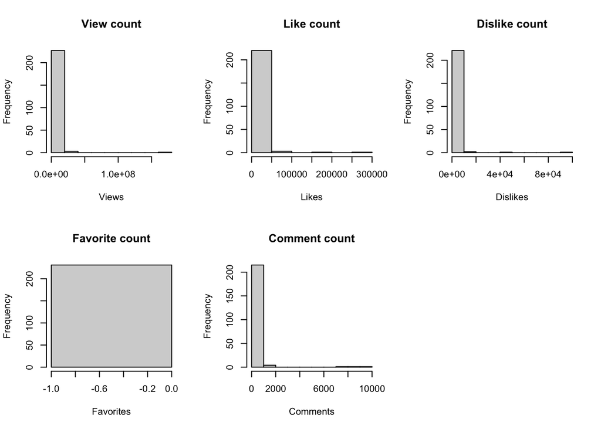

```r
# view distribution
par(mfrow = c(2,3))  # 一次性画多个直方图
hist(youtube$view_count, main = "View count", xlab = "Views")
hist(youtube$like_count, main = "Like count", xlab = "Likes")
hist(youtube$dislike_count, main = "Dislike count", xlab = "Dislikes")
hist(youtube$favorite_count, main = "Favorite count", xlab = "Favorites")
hist(youtube$comment_count, main = "Comment count", xlab = "Comments")
```

According to the plots:

- View count / Like count / Dislike count / Comment count: right skewed, and they need transformation before using as an outcome in a linear regression. So they fall in to category ii)
- Favorite count: only contains 0 and NAs, so it falls in the category iii), which can’t be used as an outcome in a linear regression.

## question c

```r
# transformed outcomes
youtube <- youtube %>%
  mutate(
    log_view = log1p(view_count),
    log_like = log1p(like_count),
    log_dislike = log1p(dislike_count),
    log_comment = log1p(comment_count)
  )

# List of outcomes
outcomes <- c("log_view", "log_like",
              "log_dislike", "log_comment")

# Fit a lm for each outcome
models <- lapply(outcomes, function(y) {
  formula <- as.formula(
    paste(y, "~ funny + show_product_quickly + patriotic + celebrity + danger + animals + use_sex + year")
  )
  lm(formula, data = youtube)
})

# Name the models
names(models) <- outcomes

# Summaries
lapply(models, summary)
```

```
$log_view

Call:
lm(formula = formula, data = youtube)

Residuals:
    Min      1Q  Median      3Q     Max
-7.7742 -1.6152  0.1311  1.7036  8.4481

Coefficients:
                          Estimate Std. Error t value Pr(>|t|)
(Intercept)              -31.55016   71.00538  -0.444    0.657
funnyTRUE                  0.56492    0.46702   1.210    0.228
show_product_quicklyTRUE   0.21089    0.40530   0.520    0.603
patrioticTRUE              0.50699    0.53811   0.942    0.347
celebrityTRUE              0.03548    0.42228   0.084    0.933
dangerTRUE                 0.63131    0.41812   1.510    0.132
animalsTRUE               -0.31002    0.39348  -0.788    0.432
use_sexTRUE               -0.38671    0.44782  -0.864    0.389
year                       0.02053    0.03531   0.582    0.561

Residual standard error: 2.787 on 222 degrees of freedom
  (16 observations deleted due to missingness)
Multiple R-squared:  0.02694,   Adjusted R-squared:  -0.008122
F-statistic: 0.7684 on 8 and 222 DF,  p-value: 0.631


$log_like

Call:
lm(formula = formula, data = youtube)

Residuals:
    Min      1Q  Median      3Q     Max
-5.2860 -1.6333  0.0868  1.4911  7.7431

Coefficients:
                           Estimate Std. Error t value Pr(>|t|)
(Intercept)              -150.51357   63.45723  -2.372   0.0186 *
funnyTRUE                   0.47476    0.41816   1.135   0.2575
```

[output cut: 57 more lines]

```
funnyTRUE                  0.21954    0.34528   0.636   0.5256
show_product_quicklyTRUE   0.40939    0.30229   1.354   0.1771
patrioticTRUE              0.66698    0.39902   1.672   0.0961 .
celebrityTRUE              0.29767    0.31541   0.944   0.3464
dangerTRUE                 0.17784    0.31069   0.572   0.5677
animalsTRUE               -0.26802    0.29347  -0.913   0.3621
use_sexTRUE               -0.39323    0.33163  -1.186   0.2370
year                       0.05034    0.02632   1.913   0.0571 .
---
Signif. codes:  0 '***' 0.001 '**' 0.01 '*' 0.05 '.' 0.1 ' ' 1

Residual standard error: 2.039 on 213 degrees of freedom
  (25 observations deleted due to missingness)
Multiple R-squared:  0.06535,   Adjusted R-squared:  0.03025
F-statistic: 1.862 on 8 and 213 DF,  p-value: 0.06748
```

According to the summary table:

- View Count: all ad-categorical features and year have $p > 0.1$, meaning there is no features are significant.
- Like Count: Year has a $p = 0.0157$, which is less than 0.05, and estimate = 0.07685. This indicates that in more recent years, the like count has more
- Dislike Count: The year feature has an estimate = 0.092, with $p < 0.001$. This indicates that the dislikes have grown over time
- Comment Count: the year features has an estimate = 0.05034, with $p < 0.1$. And the patriotic feature has an estimate = 0.66698, with a $p < 0.1$. These indicates that there are weak evidences to support that time and patriotism increase comments.

## question d

```r
## Build the frame (log outcome + predictors)
df <- within(youtube, {
  log_view_count <- log1p(view_count)
})

## keep variables, drop rows with any NA
df <- df[, c("log_view_count","funny","show_product_quickly","patriotic",
             "celebrity","danger","animals","use_sex","year")]
df <- df[complete.cases(df), ]

## Design matrix X (with intercept) and response y
X <- model.matrix(~ funny + show_product_quickly + patriotic +
                    celebrity + danger + animals + use_sex + year,
                  data = df)
y <- df$log_view_count

n <- nrow(X); p <- ncol(X)

## OLS via normal equations
XtX <- crossprod(X)             # t(X) %*% X
Xty <- crossprod(X, y)          # t(X) %*% y
beta_hat <- solve(XtX, Xty)     # coefficients

# use lm
fit_lm <- lm(log1p(view_count) ~ funny + show_product_quickly + patriotic +
               celebrity + danger + animals + use_sex + year,
             data = youtube)

all.equal(unname(coef(fit_lm)), as.numeric(beta_hat))
```

```
[1] TRUE
```

Both mannually computation and calculation using lm() get the same results.